## Starbucks Customer Reviews: NLP and Sentiment Analysis

### Background:

##### This dataset contains a comprehensive collection of consumer reviews and ratings for Starbucks, a renowned coffeehouse chain. The data was collected through web scraping and includes textual reviews, star ratings, location information, and image links from multiple pages on the ConsumerAffairs website. It offers valuable insights into customer sentiment and feedback about Starbucks locations.

### Objective :

##### To analyze customer sentiment in online reviews of Starbucks locations and products.

### Import Libraries

```r
library(tm)
library(sentimentr)
library(tidyverse)
library(wordcloud)
```

### Import Data

```r
data<-read.csv("reviews_data.csv",header=TRUE)
head(data)
```

```
      name          location           Date Rating
1    Helen Wichita Falls, TX  Sept 13, 2023      5
2 Courtney        Apopka, FL  July 16, 2023      5
3 Daynelle Cranberry Twp, PA   July 5, 2023      5
4   Taylor       Seattle, WA   May 26, 2023      5
5  Tenessa       Gresham, OR   Jan 22, 2023      5
6   Alyssa     Sunnyvale, TX  Sept 14, 2023      1
                                                                                                                                                                                                                                                                                                            …
1                                                                                                                                                                                                                                   Amber and LaDonna at the Starbucks on Southwest Parkway are always so wa…
2 ** at the Starbucks by the fire station on 436 in Altamonte Springs, FL made my day and finally helped me figure out the way to make my drink so I’d love it. She took time out to talk to me for 2 minutes to make my experience better than what I’m used to. It was much appreciated! I’ve had bad expe…
3                                                                                                                                                                                                               I just wanted to go out of my way to recognize a Starbucks employee Billy at the Franklin Pa…
4                                                                                                                     Me and my friend were at Starbucks and my card didn’t work. Thankful the worker there, paid for our drinks. And was very nice about it, it didn’t seem to bother him that he paid for …
5                                                                                                                                                         I’m on this kick of drinking 5 cups of warm water. I work for Instacart right now and every location of Starbucks I was given free hot water becau…
6                                                                                                                                                                                                                                  We had to correct them on our order 3 times. They never got it right then…
```

```r
str(data)
```

```
'data.frame':   812 obs. of  5 variables:
 $ name    : chr  "Helen" "Courtney" "Daynelle" "Taylor" ...
 $ location: chr  "Wichita Falls, TX" "Apopka, FL" "Cranberry Twp, PA" "Seattle, WA" ...
 $ Date    : chr  " Sept 13, 2023" " July 16, 2023" " July 5, 2023" " May 26, 2023" ...
 $ Rating  : int  5 5 5 5 5 1 1 1 1 1 ...
 $ Review  : chr  "Amber and LaDonna at the Starbucks on Southwest Parkway are always so warm and welcoming. There is always a smi"| __truncated__ "** at the Starbucks by the fire station on 436 in Altamonte Springs, FL made my day and finally helped me figur"| __truncated__ "I just wanted to go out…
```

### Analysis Steps:

1. Text Pre-processing
2. Creation of WordCloud
3. Sentiment Analysis - By Year

### 1) Text Pre-processing

```r
# Convert Reviews to lowercase.
data$Cleaned_Review <- tolower(data$Review)

# Remove stop words like: i, me, our and, the, is, etc.
data$Cleaned_Review <- removeWords(data$Cleaned_Review, stopwords("en"))

# Remove all characters(#$",@, etc.) except alphabets, numbers, and spaces.
data$Cleaned_Review <- gsub("[^[:alnum:][:space:]]", "", data$Cleaned_Review)

# Remove numbers from the text
data$Cleaned_Review <- gsub("[0-9]", "", data$Cleaned_Review)

# Remove words that are obvious
data$Cleaned_Review <- removeWords(data$Cleaned_Review, c("drinks", "starbucks", "coffee", "order", "cafe"))

#Remove any leading or trailing whitespace and Reduce sequence of whitespace to a single space.
data$Cleaned_Review <- str_squish(data$Cleaned_Review)
```

### Checking “Reviews” before and after cleaning

```r
data$Review[1]     # Before cleaning
```

```
[1] "Amber and LaDonna at the Starbucks on Southwest Parkway are always so warm and welcoming. There is always a smile in their voice when they greet you at the drive-thru. And their customer service is always spot-on, they always get my order right and with a smile. I would actually give them more …
```

```r
data$Cleaned_Review[1]   # After cleaning
```

```
[1] "amber ladonna southwest parkway always warm welcoming always smile voice greet drivethru customer service always spot always get right smile actually give stars available"
```

### 2) Creating Word Clouds from Text and Visualizing Reviews

Based on the “Rating” column we will plot two Word clouds as follows:

1. Reviews for customers with rating > 3
2. Reviews for customers with rating < 3

Here, Rating = 3, is neutral

```r
# The code filters data for reviews with Ratings above 3, extracts words from Cleaned_Review column, counts their occurrences, and sorts them by frequency.
positive_reviews <-subset(data,Rating>3)
positive_reviews <- positive_reviews %>%
  dplyr::select(Cleaned_Review) %>%
  tidytext::unnest_tokens(word, Cleaned_Review) %>%
  dplyr::count(word, sort = TRUE) %>%
  ungroup()
head(positive_reviews, 2)
```

```
     word  n
1  always 60
2 service 55
```

```r
# The code filters data for reviews with Ratings below 3, extracts words from Cleaned_Review column, counts their occurrences, and sorts them by frequency.
negative_reviews <-subset(data,Rating<3)
negative_reviews <- negative_reviews %>%
  dplyr::select(Cleaned_Review) %>%
  tidytext::unnest_tokens(word, Cleaned_Review) %>%
  dplyr::count(word, sort = TRUE) %>%
  ungroup()
head(negative_reviews, 2)
```

```
      word   n
1 customer 236
2    drink 234
```

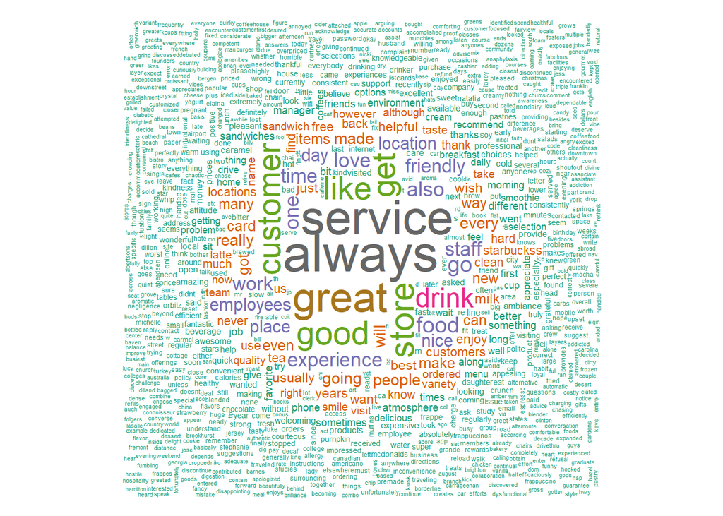

```r
pal <- brewer.pal(8,"Dark2")
# Word cloud for Positive Reviews:
wordcloud(positive_reviews$word, positive_reviews$n, random.order = FALSE, min.freq =1, scale=c(3,.3), colors=pal)
```

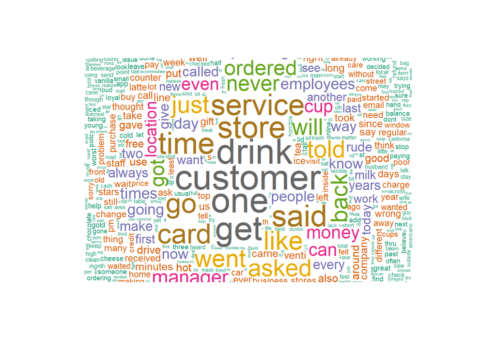

```r
# Word cloud for Negative Reviews:
wordcloud(negative_reviews$word, negative_reviews$n, random.order = FALSE, min.freq =1, scale=c(3,.3), colors=pal)
```

### 3) Calculating Sentiment Scores

##### The “sentiment()” function from sentimentr package analyzes text and computes a sentiment score for each entry, which is then stored. The resulting score represents the overall sentiment or sentiment polarity of each text entry in the dataset. A positive score typically indicates a positive sentiment in the text, while a negative score suggests a negative sentiment, with the magnitude of the score indicating the strength of the sentiment.

```r
#Perform sentiment analysis on the cleaned reviews.
data$Compound_Score<-sentiment(data$Cleaned_Review)$sentiment
head(data, 3)
```

```
      name          location           Date Rating
1    Helen Wichita Falls, TX  Sept 13, 2023      5
2 Courtney        Apopka, FL  July 16, 2023      5
3 Daynelle Cranberry Twp, PA   July 5, 2023      5
                                                                                                                                                                                                                                                                                                            …
1                                                                                                                                                                                                                                   Amber and LaDonna at the Starbucks on Southwest Parkway are always so wa…
2 ** at the Starbucks by the fire station on 436 in Altamonte Springs, FL made my day and finally helped me figure out the way to make my drink so I’d love it. She took time out to talk to me for 2 minutes to make my experience better than what I’m used to. It was much appreciated! I’ve had bad expe…
3                                                                                                                                                                                                               I just wanted to go out of my way to recognize a Starbucks employee Billy at the Franklin Pa…
                                                                                                                                                                                                                                                                                                            …
1                                                                                                                                                    amber ladonna southwest parkway always warm welcoming always smile voice greet drivethru customer service always spot always get right smile actually g…
2 fire station altamonte springs fl made day finally helped figure way make drink d love took time talk minutes make experience better m used much appreciated ve bad experiences one another s closest work building great along great customer service specific starbuckss niko refreshing speak pleasant …
3                                                                                                                 just wanted go way recognize employee billy franklin park location running late work placed wrong location make smile made within seconds thank soo much bad morning people like just make…
  Compound_Score
1      1.1022704
2      0.9285714
3      0.2175971
```

### Analyzing Sentiment Trends (Compound Score) Over Recent Years

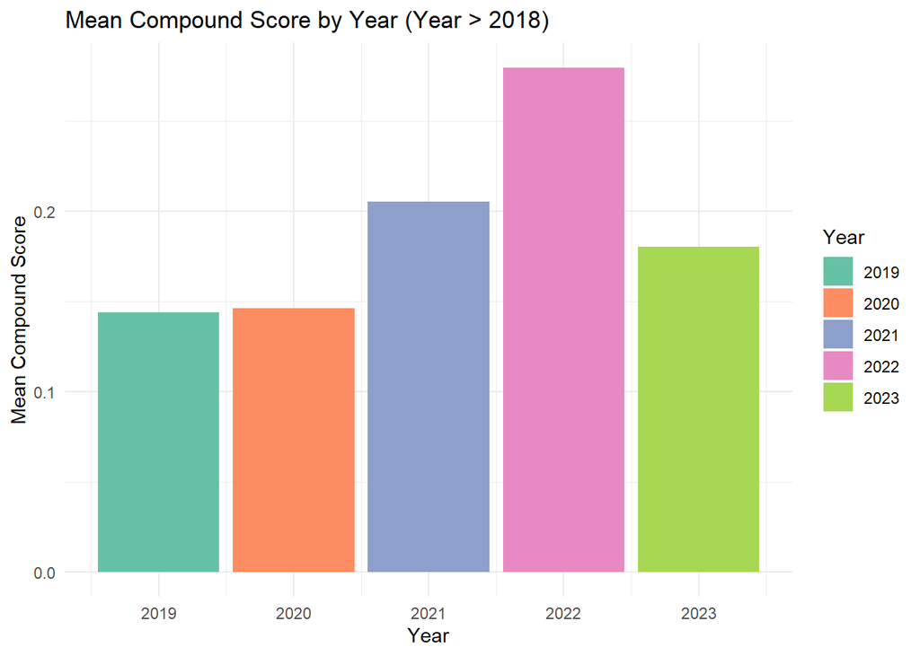

```r
# Extracting Year from Date column.
# str_split will split "Sept 13, 2023" into Sept 13 and 2023, we will need the 2nd half hence, x[[2]]
data$Year <- str_split(data$Date, ", ") %>% sapply(function(x) x[[2]])
data$Year<-as.numeric(data$Year)
recentdata <- subset(data,Year > 2018)

mean_scores_by_year <-recentdata %>% group_by(Year) %>%
  summarise(`Compound Score`= mean(Compound_Score))

ggplot(data = mean_scores_by_year, aes(x = Year, y = `Compound Score`, fill = as.factor(Year))) +
  geom_bar(stat = "identity", position = "dodge") + scale_fill_brewer(palette = "Set2") +
  labs(title = "Mean Compound Score by Year (Year > 2018)",x = "Year",y = "Mean Compound Score",fill="Year") +
  theme_minimal()
```

#### **Observations :**

##### - There is some variation in the compound sentiment scores across the years, with 2021 and 2022 showing the highest mean compound score and 2019 showing the lowest. This indicates potential fluctuations in sentiment in different years.